# DESeq2 with phyloseq

J. Ignacio Lucas Lledó

16/3/2020

Here the goal is to test for differential abundance of taxa between age groups (early and late life points). Data are counts: number of times an amplicon variant has been observed. The counts depend on the library size or sequencing effort, which varies among samples. They only carry relative information. They are *compositional* data. Comparisons among these kinds of data are not straight forward for several reasons. First of all, data are not normally distributed. A Poisson distribution would adequately model count data if the average was the same in all replicates. But there is *biological variation* among replicates: the proportion of any taxon is not expected to be exactly the same among replicates of the same class of samples, for biological (rather than technicall or random-sampling) reasons. Such variation among replicates causes overdispersion, with respect to the Poisson distribution. If not taken into account, overdispersion leads to an inflated number of false positives (Anders and Huber 2010). A Gamma mixture of Poisson variables produces a Negative Binomial distribution, which more adequately models sequence count data (Lu, Tomfohr, and Kepler 2005). The main challenge to fit such models is to estimate the dispersion parameter (for every taxon) from a limited number of replicates. The strategy involves sharing information among features (taxa), and assuming that taxa with a similar average abundance must have a similar level of variation among replicates. This kind of methods are implemented in R packages for the analysis of RNA-seq data, such as `EdgeR` and `DSeq2`. Here, we apply `DSeq2` (Love, Huber, and Anders 2014) to the analysis of microbial composition data (McMurdie 2014).

To my knowldege, neigther `DSeq2` nor `EdgeR` take into account another particular feature of this kind of data. The compositional nature of the counts imply a dependence structure: one taxon cannot increase its abundance without decreasing every other taxa’s abundances. This concern is gaining attention (Quinn et al. 2019). However, a common understanding is perceived that if compositional changes are small, then it does not make a big difference to take such dependence into account.

# Comparison of abundances between early and late

```r
# I had set isoline as 'ordered' just to have isoline 6 in first position in plots.
# Now, I should *disorder* it.
sample_data(ps)$isoline <- factor(sample_data(ps)$isoline, ordered=FALSE)
ds <- phyloseq_to_deseq2(ps, ~ seqrun + isoline + age)
# ds <- DESeq(ds, test='Wald', fitType='parametric')
# The DESeq function performs three steps that can be run independently:
# ds <- estimateSizeFactors(ds)
stopifnot(all.equal(rownames(SeqTabNoChim), colnames(ds)))
sizeFactors(ds) <- rowSums(SeqTabNoChim)
# This filtering did not improve convergence:
#   f  <- rowSums(counts(ds) >= 10) >= 4
#   ds <- ds[f,]
#   ds <- estimateSizeFactors(ds)

ds <- estimateDispersions(ds, fitType = 'local')
ds0 <- nbinomWaldTest(ds)
```

```
## 1 rows did not converge in beta, labelled in mcols(object)$betaConv. Use larger maxit argument with nbinomWaldTest
```

```r
dim(ds0)
```

```
## [1] 1247  177
```

```r
ds0 <- ds0[mcols(ds0)$betaConv, ]
dim(ds0)
```

```
## [1] 1246  177
```

```r
res <- results(ds0, cooksCutoff = FALSE)
sum(is.na(res$padj))
```

```
## [1] 483
```

```r
res[is.na(res$padj),'padj'] <- 9.9999
sigtab <- res[res$padj < 0.05, ]
sigtab = cbind(as(sigtab, "data.frame"), as(tax_table(ps)[rownames(sigtab), ], "matrix"))
dim(sigtab)
```

```
## [1] 141  13
```

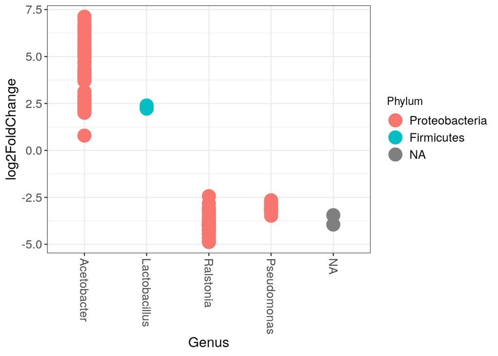

```r
theme_set(theme_bw())
scale_fill_discrete <- function(palname = "Set1", ...) {
    scale_fill_brewer(palette = palname, ...)
}
# Phylum order
x = tapply(sigtab$log2FoldChange, sigtab$Phylum, function(x) max(x))
x = sort(x, TRUE)
sigtab$Phylum = factor(as.character(sigtab$Phylum), levels=names(x))
# Genus order
x = tapply(sigtab$log2FoldChange, sigtab$Genus, function(x) max(x))
x = sort(x, TRUE)
sigtab$Genus = factor(as.character(sigtab$Genus), levels=names(x))
ggplot(sigtab, aes(x=Genus, y=log2FoldChange, color=Phylum)) + geom_point(size=6) +
  theme(axis.text.x = element_text(angle = -90, hjust = 0, vjust=0.5, size=12),
        axis.text.y = element_text(size=12), axis.title = element_text(size=14),
        legend.text = element_text(size=12))
```

```r
ggsave('FoldChange.png')
```